# 5.0.2 GO enrichment

# Gene Ontology (GO) enrichment

Upset plot of orthogroups, as done in [Cossard et al. 2022 Nat Ecol Evol](https://www.nature.com/articles/s41559-022-01692-4) Extended Data Fig. 1. We can assess whether certain GO categories are enriched. We use `Fisher’s exact` test statistics with the `parent-child algorithm` as implemented in `TopGO`.

```r
library(tidyverse)
```

## Load data

### Load interproscan data

```r
GO_Fs <- readr::read_delim("data/Interproscan/Fs_ips/F_serratus_pep.filt.processed.faa.tsv",
                    delim = "\t", col_select = c(1,14)) %>%
  drop_na() %>%
  filter(GO_term != "-") %>%
  separate_rows(GO_term, sep = "\\|") %>%
  dplyr::mutate(GeneID = str_remove(GeneID, "\\.[^.]+$")) %>%
  arrange(GeneID) %>%
  distinct()
GO_Fd <- readr::read_delim("data/Interproscan/Fd_ips/F_distichus_pep.filt.processed.faa.tsv",
                    delim = "\t", col_select = c(1,14)) %>%
  drop_na() %>%
  filter(GO_term != "-") %>%
  separate_rows(GO_term, sep = "\\|") %>%
  dplyr::mutate(GeneID = str_remove(GeneID, "\\.[^.]+$")) %>%
  arrange(GeneID) %>%
  distinct()
length(unique(GO_Fs$GO_term))
length(unique(GO_Fs$GeneID))
```

There are 30,007 GO terms (whereof 2,040 are unique) attached to 12,672 genes in Fucus serratus.

```r
length(unique(GO_Fd$GO_term))
length(unique(GO_Fd$GeneID))
```

```r
Fs_ddsObj.wald_nonDEGlist <-
  base::readRDS("data/Fs_wald_nonDEG_list.rds")
Fd_ddsObj.wald_nonDEGlist <-
  base::readRDS("data/Fd_wald_nonDEG_list.rds")
```

```r
resnonDEG_24H48H <- Fs_ddsObj.wald_nonDEGlist[[1]] %>%
        tibble::as_tibble(rownames = "GeneID") %>%
        dplyr::mutate(stage = "24H_to_48H") %>%
        dplyr::mutate(test = "nonDEG") %>%
        dplyr::mutate(species = "Fs")
resnonDEG_48H1w <- Fs_ddsObj.wald_nonDEGlist[[2]] %>%
        tibble::as_tibble(rownames = "GeneID") %>%
        dplyr::mutate(stage = "48H_to_1w") %>%
        dplyr::mutate(test = "nonDEG") %>%
        dplyr::mutate(species = "Fs")
resnonDEG_1w3w <- Fs_ddsObj.wald_nonDEGlist[[3]] %>%
        tibble::as_tibble(rownames = "GeneID") %>%
        dplyr::mutate(stage = "1w_to_3w") %>%
        dplyr::mutate(test = "nonDEG") %>%
        dplyr::mutate(species = "Fs")
resnonDEG_3w4w <- Fs_ddsObj.wald_nonDEGlist[[4]] %>%
        tibble::as_tibble(rownames = "GeneID") %>%
        dplyr::mutate(stage = "3w_to_4w") %>%
        dplyr::mutate(test = "nonDEG") %>%
        dplyr::mutate(species = "Fs")

resnonDEG_E1E2_Fd <- Fd_ddsObj.wald_nonDEGlist[[1]] %>%
        tibble::as_tibble(rownames = "GeneID") %>%
        dplyr::mutate(stage = "1E_to_2E") %>%
        dplyr::mutate(test = "nonDEG") %>%
        dplyr::mutate(species = "Fd")
resnonDEG_E2E3_Fd <- Fd_ddsObj.wald_nonDEGlist[[2]] %>%
        tibble::as_tibble(rownames = "GeneID") %>%
        dplyr::mutate(stage = "2E_to_3E") %>%
        dplyr::mutate(test = "nonDEG") %>%
        dplyr::mutate(species = "Fd")
resnonDEG_E3E4_Fd <- Fd_ddsObj.wald_nonDEGlist[[3]] %>%
        tibble::as_tibble(rownames = "GeneID") %>%
        dplyr::mutate(stage = "3E_to_4E") %>%
        dplyr::mutate(test = "nonDEG") %>%
        dplyr::mutate(species = "Fd")
resnonDEG_E4E5_Fd <- Fd_ddsObj.wald_nonDEGlist[[4]] %>%
        tibble::as_tibble(rownames = "GeneID") %>%
        dplyr::mutate(stage = "4E_to_5E") %>%
        dplyr::mutate(test = "nonDEG") %>%
        dplyr::mutate(species = "Fd")
resnonDEG_E5E6_Fd <- Fd_ddsObj.wald_nonDEGlist[[5]] %>%
        tibble::as_tibble(rownames = "GeneID") %>%
        dplyr::mutate(stage = "5E_to_6E") %>%
        dplyr::mutate(test = "nonDEG") %>%
        dplyr::mutate(species = "Fd")

combined_table <- rbind(resnonDEG_24H48H, resnonDEG_48H1w, resnonDEG_1w3w, resnonDEG_3w4w,
                        resnonDEG_E1E2_Fd, resnonDEG_E2E3_Fd, resnonDEG_E3E4_Fd, resnonDEG_E4E5_Fd, resnonDEG_E5E6_Fd)
```

```r
# library(ggfortify)
library(corrplot)
library(myTAI)
library(ComplexHeatmap)
source("functions/parse_orthogroups.R")
library(topGO)
make_list_UpSet <- function(INPUT_table, padj_threshold = 0.1, DEG_type, species_name, make_list = T){
  FILTER_INPUT <- INPUT_table %>%
    dplyr::filter(padj < padj_threshold) %>%
    dplyr::filter(test == DEG_type) %>%
    dplyr::filter(species == species_name) %>%
    dplyr::select(GeneID, stage)
  if(make_list == F) {
    return(FILTER_INPUT)
  }
  OUT <- utils::unstack(FILTER_INPUT, GeneID ~ stage)
  return(OUT)
}
```

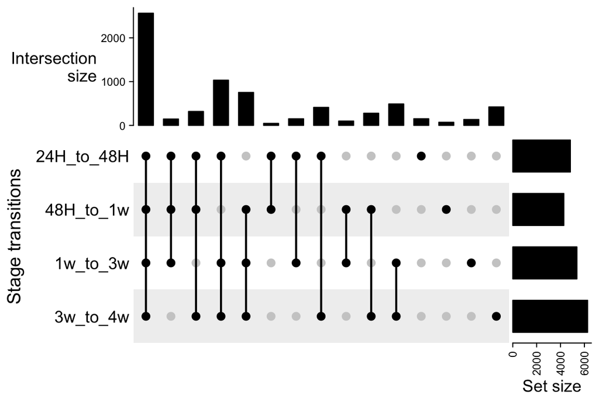

```r
GeneList <- make_list_UpSet(combined_table, padj_threshold = 0.1, DEG_type = "nonDEG", species_name = "Fs")
upsetting_input_distinct <- ComplexHeatmap::make_comb_mat(GeneList, mode = "distinct")
ComplexHeatmap::UpSet(upsetting_input_distinct,
                      set_order = c(2,4,1,3),
                      row_title = "Stage transitions")
```

```r
GO_GeneList_Fs <- make_list_UpSet(combined_table, padj_threshold = 0.1, DEG_type = "nonDEG", species_name = "Fs", make_list = F) %>%
  dplyr::mutate(seen = 1) %>%
  pivot_wider(names_from = stage, values_from = seen) %>%
  drop_na() %>%
  dplyr::select(GeneID)
```

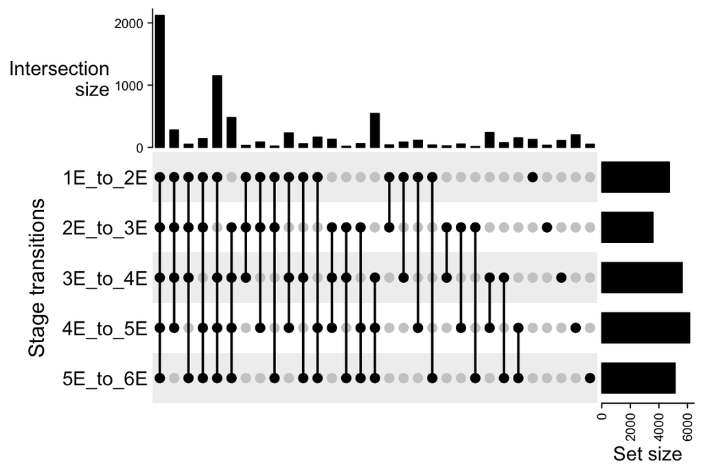

```r
GeneList <- make_list_UpSet(combined_table, padj_threshold = 0.1, DEG_type = "nonDEG", species_name = "Fd")
upsetting_input_distinct <- ComplexHeatmap::make_comb_mat(GeneList, mode = "distinct")
ComplexHeatmap::UpSet(upsetting_input_distinct,
                      set_order = c(1,2,3,4,5),
                      row_title = "Stage transitions")
```

```r
GO_GeneList_Fd <- make_list_UpSet(combined_table, padj_threshold = 0.1, DEG_type = "nonDEG", species_name = "Fd", make_list = F) %>%
  dplyr::mutate(seen = 1) %>%
  pivot_wider(names_from = stage, values_from = seen) %>%
  drop_na() %>%
  dplyr::select(GeneID)
```

I must admit, what you just witnessed is a mess but I just wanted to string together code from old analyses.

What is the number of rows.

```r
nrow(GO_GeneList_Fs)
```

```
## [1] 2562
```

```r
nrow(GO_GeneList_Fd)
```

```
## [1] 2118
```

### process GO data

```r
createGOdata <- function(geneList, ontology, gene2GO_map, nodeSize){
  OUT <-
    methods::new(
      "topGOdata",
      description = paste("GOtest", ontology, sep = "_"),
      ontology = ontology,
      allGenes = geneList,
      annot = annFUN.gene2GO,
      gene2GO = gene2GO_map,
      nodeSize = nodeSize)
  return(OUT)
}
```

`processedGOdata()` wraps around my function `createGOdata()`

```r
processedGOdata <-
  function(DEG_contrasts, GO_data, GO_gene_mapping, ontology, nodeSize = 10, padj_threshold = 0.05){
    # GO_background <-
    #   dplyr::left_join(DEG_contrasts, GO_data) %>%
    #   tidyr::drop_na()
    # GO_query <-
    #   dplyr::filter(GO_background, padj < 0.05)
    # geneList <-
    #   factor(as.integer(GO_background$GeneID %in% GO_query$GeneID))
    # names(geneList) <- GO_background$GeneID
    gene_background <-
      DEG_contrasts %>%
      tidyr::drop_na()
    gene_query <-
      dplyr::filter(gene_background, padj < padj_threshold)
    geneList <-
      factor(as.integer(gene_background$GeneID %in% gene_query$GeneID))
    names(geneList) <- gene_background$GeneID
    myGOdata <-
      createGOdata(
        geneList,
        ontology = ontology,
        gene2GO_map = GO_gene_mapping,
        nodeSize = nodeSize
        )
    return(myGOdata)
  }
```

To use `processedGOdata()`

```r
myGOdata_CC <-
  processedGOdata(
    DEG_contrasts = dplyr::filter(Fs_DEG_contrasts, contrast == "48H vs 24H"),
    GO_data = GO_Fs,
    GO_gene_mapping = GO_Fs_gene_mapping,
    ontology = "CC")
```

`resultGO()` plots or outputs the significant GO terms.

```r
resultGO <- function(GOdata, algorithm, firstSigNodes = 5, sig = F, plot = F, fisher_adjusted_threshold = 0.1){
  ## Calculate fisher exact test
  result_fisher <-
    topGO::runTest(
      object = GOdata,
      algorithm = algorithm,
      statistic = "fisher")
  OUT <-
    topGO::GenTable(
      object  = GOdata,
      fisher = result_fisher,
      topNodes = length(score(result_fisher)))

  ## Correct for multiple testing:
  OUT$fisher <- as.numeric(OUT$fisher)
  OUT$fisher_adjusted <-
    stats::p.adjust(p = OUT$fisher, method = c("fdr"))
  if(sig == F & plot == F){
    return(OUT)
  }
  ## Subset calls with significance higher than expected:
  if(plot == F){
    OUT_sig <-
      OUT %>%
      dplyr::filter(fisher_adjusted < fisher_adjusted_threshold) %>%
      dplyr::select(GO.ID, Term, Significant, Expected, fisher, fisher_adjusted)
    return(OUT_sig)
  }
  plot_OUT <-
    topGO::showSigOfNodes(
      GOdata,
      score(result_fisher),
      firstSigNodes = firstSigNodes,
      useInfo ='all')
  return(plot_OUT)
}
# also possible
# resGO_sig <- resultGO(myGOdata, "weight01", firstSigNodes = 10, sig = T)
```

The script above were motivated three blogposts:

-[Archetypalecology](https://archetypalecology.wordpress.com/2021/01/27/how-to-perform-kegg-and-go-enrichment-analysis-of-non-model-species-using-r/)

-[Avrilomics](https://avrilomics.blogspot.com/2015/07/using-topgo-to-test-for-go-term.html)

-[Zhiganglu](https://zhiganglu.com/post/topgo-ks-test/)

> CC = Cellular Compartment MF = Molecular Function BP = Biological Process

```r
GO_Fs_gene_mapping <- base::split(GO_Fs$GO_term, GO_Fs$GeneID)
GO_Fd_gene_mapping <- base::split(GO_Fd$GO_term, GO_Fd$GeneID)
```

Here, I used `base::split()` rather than `topGO::readMapping()` because I have already loaded the `GO_Fs` and `GO_Fd` data. With `topGO::readMapping()`, GeneIDs with multiple GO terms are read (as expected) but (probably due to the GO annotations in different isoforms or different interproscan tools - not sure), we get duplicated element names in the output list.

```r
> read_delim("data/Interproscan/Fs_ips/F_serratus_pep.filt.processed.faa.tsv",
+            delim = "\t", col_select = c(1,14)) %>%
+     drop_na() %>%
+     filter(GO_term != "-") %>%
+     dplyr::mutate(GeneID = str_remove(GeneID, "\\.[^.]+$")) %>%
+     distinct() %>%
+     write_csv("GO_input/temp_GOmap_Fs.csv")
Rows: 247635 Columns: 2
── Column specification ────────────────────────────────────────────────────────────────────────────────────────────────────────
Delimiter: "\t"
chr (2): GeneID, GO_term

ℹ Use `spec()` to retrieve the full column specification for this data.
ℹ Specify the column types or set `show_col_types = FALSE` to quiet this message.
Warning message:
One or more parsing issues, call `problems()` on your data frame for details, e.g.:
  dat <- vroom(...)
  problems(dat)
>
> gene_to_go_mapping <- readMappings(file = "GO_input/temp_GOmap_Fs.csv", sep = ",", IDsep = "\\|")
> table(duplicated(names(gene_to_go_mapping)))

FALSE  TRUE
12673  5775
> head(names(gene_to_go_mapping)[duplicated(names(gene_to_go_mapping))])
[1] "ser_TRINITY_DN30930_c0_g1"  "ser_TRINITY_DN1578_c0_g1"   "ser_TRINITY_DN11998_c0_g1"
[4] "ser_TRINITY_DN11998_c0_g1"  "ser_TRINITY_DN3705_c0_g2"   "ser_TRINITY_DN166159_c0_g1"
```

Compare this to

```r
> table(duplicated(names(GO_Fs_gene_mapping)))

FALSE
12672
> head(names(GO_Fs_gene_mapping)[duplicated(names(GO_Fs_gene_mapping))])
character(0)
```

# GO×nonDEG analysis

## Fucus distichus

### nonDEG (Wald)

```r
gene_background_unique <- combined_table %>%
  dplyr::filter(species == "Fd") %>%
  dplyr::select(GeneID) %>%
  unique()

geneList <-
  factor(as.integer(gene_background_unique$GeneID %in% GO_GeneList_Fd$GeneID))
names(geneList) <- gene_background_unique$GeneID
myGOdata_CC <-
  createGOdata(
    geneList,
    ontology = "CC",
    gene2GO_map = GO_Fd_gene_mapping,
    nodeSize = 10
    )
myGOdata_BP <-
  createGOdata(
    geneList,
    ontology = "BP",
    gene2GO_map = GO_Fd_gene_mapping,
    nodeSize = 10
    )
myGOdata_MF <-
  createGOdata(
    geneList,
    ontology = "MF",
    gene2GO_map = GO_Fd_gene_mapping,
    nodeSize = 10
    )

resGO_CC <-
  resultGO(myGOdata_CC, algorithm = "parentchild", sig = T)
resGO_BP <-
  resultGO(myGOdata_BP, algorithm = "parentchild", sig = T)
resGO_MF <-
  resultGO(myGOdata_MF, algorithm = "parentchild", sig = T)
```

```r
resGO_CC %>%
  dplyr::filter(fisher_adjusted < 0.1) %>%
  dplyr::select(GO.ID, Term, fisher, Significant, Expected)
```

| GO.ID | Term | fisher | Significant | Expected |
| --- | --- | --- | --- | --- |
| GO:0043231 | intracellular membrane-bounded organelle | 4.600e-11 | 112 | 81.92 |
| GO:0043227 | membrane-bounded organelle | 2.300e-09 | 112 | 84.96 |
| GO:0005737 | cytoplasm | 5.200e-08 | 89 | 59.67 |
| GO:0048475 | coated membrane | 4.300e-05 | 16 | 7.42 |
| GO:0012505 | endomembrane system | 2.300e-04 | 35 | 21.91 |
| GO:0005622 | intracellular anatomical structure | 2.300e-04 | 193 | 172.95 |
| GO:0032991 | protein-containing complex | 4.700e-04 | 150 | 125.75 |
| GO:0099023 | vesicle tethering complex | 5.200e-04 | 12 | 4.72 |
| GO:0098796 | membrane protein complex | 6.400e-04 | 36 | 23.26 |
| GO:0031975 | envelope | 4.220e-03 | 15 | 8.43 |

[output cut: 5 more lines]

```r
resGO_BP %>%
  dplyr::filter(fisher_adjusted < 0.1) %>%
  dplyr::select(GO.ID, Term, fisher, Significant, Expected)
```

| GO.ID | Term | fisher | Significant | Expected |
| --- | --- | --- | --- | --- |
| GO:0046907 | intracellular transport | 1.600e-09 | 60 | 32.45 |
| GO:0051649 | establishment of localization in cell | 1.600e-09 | 60 | 32.45 |
| GO:0016192 | vesicle-mediated transport | 6.000e-09 | 50 | 25.38 |
| GO:0051641 | cellular localization | 1.700e-07 | 63 | 37.26 |
| GO:0016071 | mRNA metabolic process | 9.900e-07 | 46 | 21.52 |
| GO:0043038 | amino acid activation | 2.300e-06 | 18 | 8.35 |
| GO:0006418 | tRNA aminoacylation for protein translat... | 1.400e-05 | 18 | 8.03 |
| GO:0045184 | establishment of protein localization | 4.600e-05 | 42 | 24.74 |
| GO:0046483 | heterocycle metabolic process | 4.700e-05 | 229 | 203.35 |
| GO:0006725 | cellular aromatic compound metabolic pro... | 1.600e-04 | 224 | 200.78 |

[output cut: 39 more lines]

```r
resGO_MF %>%
  dplyr::filter(fisher_adjusted < 0.1) %>%
  dplyr::select(GO.ID, Term, fisher, Significant, Expected)
```

| GO.ID | Term | fisher | Significant | Expected |
| --- | --- | --- | --- | --- |
| GO:0140098 | catalytic activity, acting on RNA | 0.000066 | 59 | 33.34 |
| GO:0016787 | hydrolase activity | 0.000071 | 192 | 158.46 |
| GO:0005488 | binding | 0.000120 | 734 | 686.78 |
| GO:0140640 | catalytic activity, acting on a nucleic ... | 0.000260 | 87 | 64.55 |
| GO:0016875 | ligase activity, forming carbon-oxygen b... | 0.000270 | 18 | 7.95 |
| GO:0003676 | nucleic acid binding | 0.001260 | 188 | 151.73 |
| GO:0098772 | molecular function regulator activity | 0.001730 | 26 | 15.60 |
| GO:0032561 | guanyl ribonucleotide binding | 0.001920 | 38 | 24.47 |
| GO:0019001 | guanyl nucleotide binding | 0.002580 | 38 | 24.78 |
| GO:0005525 | GTP binding | 0.002780 | 38 | 24.47 |

[output cut: 3 more lines]

## Fucus serratus

### nonDEG (Wald)

```r
gene_background_unique <- combined_table %>%
  dplyr::filter(species == "Fs") %>%
  dplyr::select(GeneID) %>%
  unique()

geneList <-
  factor(as.integer(gene_background_unique$GeneID %in% GO_GeneList_Fs$GeneID))
names(geneList) <- gene_background_unique$GeneID
myGOdata_CC <-
  createGOdata(
    geneList,
    ontology = "CC",
    gene2GO_map = GO_Fs_gene_mapping,
    nodeSize = 10
    )
myGOdata_BP <-
  createGOdata(
    geneList,
    ontology = "BP",
    gene2GO_map = GO_Fs_gene_mapping,
    nodeSize = 10
    )
myGOdata_MF <-
  createGOdata(
    geneList,
    ontology = "MF",
    gene2GO_map = GO_Fs_gene_mapping,
    nodeSize = 10
    )

resGO_CC <-
  resultGO(myGOdata_CC, algorithm = "parentchild", sig = T)
resGO_BP <-
  resultGO(myGOdata_BP, algorithm = "parentchild", sig = T)
resGO_MF <-
  resultGO(myGOdata_MF, algorithm = "parentchild", sig = T)
```

```r
resGO_CC %>%
  dplyr::filter(fisher_adjusted < 0.1) %>%
  dplyr::select(GO.ID, Term, fisher, Significant, Expected)
```

| GO.ID | Term | fisher | Significant | Expected |
| --- | --- | --- | --- | --- |
| GO:0043231 | intracellular membrane-bounded organelle | 2.600e-09 | 116 | 80.20 |
| GO:0043227 | membrane-bounded organelle | 1.200e-08 | 117 | 82.35 |
| GO:0005654 | nucleoplasm | 1.600e-06 | 15 | 5.73 |
| GO:0032991 | protein-containing complex | 1.400e-05 | 155 | 124.60 |
| GO:0048475 | coated membrane | 4.000e-05 | 17 | 8.24 |
| GO:0031974 | membrane-enclosed lumen | 5.100e-05 | 24 | 12.53 |
| GO:0005737 | cytoplasm | 5.900e-05 | 86 | 63.73 |
| GO:0043233 | organelle lumen | 2.100e-04 | 24 | 12.53 |
| GO:0070013 | intracellular organelle lumen | 2.300e-04 | 24 | 12.53 |
| GO:0005622 | intracellular anatomical structure | 2.700e-04 | 210 | 186.90 |

[output cut: 11 more lines]

```r
resGO_BP %>%
  dplyr::filter(fisher_adjusted < 0.1) %>%
  dplyr::select(GO.ID, Term, fisher, Significant, Expected)
```

| GO.ID | Term | fisher | Significant | Expected |
| --- | --- | --- | --- | --- |
| GO:0016192 | vesicle-mediated transport | 2.70e-11 | 52 | 25.78 |
| GO:0016071 | mRNA metabolic process | 9.20e-07 | 42 | 20.77 |
| GO:0051641 | cellular localization | 1.80e-06 | 68 | 43.32 |
| GO:0046907 | intracellular transport | 4.00e-06 | 60 | 37.59 |
| GO:0051649 | establishment of localization in cell | 4.00e-06 | 60 | 37.59 |
| GO:0044265 | cellular macromolecule catabolic process | 4.20e-06 | 45 | 27.21 |
| GO:0006396 | RNA processing | 1.90e-05 | 64 | 40.46 |
| GO:0009057 | macromolecule catabolic process | 2.80e-05 | 53 | 32.22 |
| GO:0033036 | macromolecule localization | 6.10e-05 | 55 | 35.45 |
| GO:0030163 | protein catabolic process | 1.90e-04 | 43 | 26.50 |

[output cut: 19 more lines]

```r
resGO_MF %>%
  dplyr::filter(fisher_adjusted < 0.1) %>%
  dplyr::select(GO.ID, Term, fisher, Significant, Expected)
```

| GO.ID | Term | fisher | Significant | Expected |
| --- | --- | --- | --- | --- |